# Project: Communicate Data Findings (Prosper Loan Data)

## Table of content

- Introduction
- Data Assessing
- Data Cleaning
- Univariate Exploration
- Bivariate Exploration
- Multivariate Exploration

## Introduction

> This data set contains 113,937 loans with 81 variables on each loan, including loan amount, borrower rate (or interest rate), current loan status, borrower income, and many others.

> The main objective of this project is to focus on communicating the findings and insights through proper data vizualization. First we will explore the data with univeriable, bivariable and multivariable exloration of different variables. Then we will built some final explainatory data visuals for storytelling.

### Some important features:

- LoanStatus : Current status of the loan like chargedoff, completed, defauted etc…
- EstimatedEffectiveYield : Yield of lenders from borrowers minus the processing fee and late fines
- BorrowerAPR : The Borrower’s Annual Percentage Rate (APR) for the loan.
- BorrowerRate : The Borrower’s interest rate for this loan.
- LoanOriginalAmount : Original amount of the loan
- LoanOriginationQuarter : Quarter of the month when loan was originated
- Term : Length of loan expressed in months

```python
# import all packages and set plots to be embedded inline
import numpy as np
import pandas as pd
import matplotlib.pyplot as plt
import seaborn as sns

%matplotlib inline
```

```python
#loading the data set and check the first five rows data
df = pd.read_csv("prosperLoanData.csv")
df.head(5)
```

|  | ListingKey | ListingNumber | ListingCreationDate | CreditGrade | Term | LoanStatus | ClosedDate | BorrowerAPR | BorrowerRate | LenderYield | ... | LP_ServiceFees | LP_CollectionFees | LP_GrossPrincipalLoss | LP_NetPrincipalLoss | LP_NonPrincipalRecoverypayments | PercentFunded | Recommendations | InvestmentFromFriendsCount | InvestmentFromFriendsAmount | Investors |
| --- | --- | --- | --- | --- | --- | --- | --- | --- | --- | --- | --- | --- | --- | --- | --- | --- | --- | --- | --- | --- | --- |
| 0 | 1021339766868145413AB3B | 193129 | 2007-08-26 19:09:29.263000000 | C | 36 | Completed | 2009-08-14 00:00:00 | 0.16516 | 0.1580 | 0.1380 | ... | -133.18 | 0.0 | 0.0 | 0.0 | 0.0 | 1.0 | 0 | 0 | 0.0 | 258 |
| 1 | 10273602499503308B223C1 | 1209647 | 2014-02-27 08:28:07.900000000 | NaN | 36 | Current | NaN | 0.12016 | 0.0920 | 0.0820 | ... | 0.00 | 0.0 | 0.0 | 0.0 | 0.0 | 1.0 | 0 | 0 | 0.0 | 1 |
| 2 | 0EE9337825851032864889A | 81716 | 2007-01-05 15:00:47.090000000 | HR | 36 | Completed | 2009-12-17 00:00:00 | 0.28269 | 0.2750 | 0.2400 | ... | -24.20 | 0.0 | 0.0 | 0.0 | 0.0 | 1.0 | 0 | 0 | 0.0 | 41 |
| 3 | 0EF5356002482715299901A | 658116 | 2012-10-22 11:02:35.010000000 | NaN | 36 | Current | NaN | 0.12528 | 0.0974 | 0.0874 | ... | -108.01 | 0.0 | 0.0 | 0.0 | 0.0 | 1.0 | 0 | 0 | 0.0 | 158 |
| 4 | 0F023589499656230C5E3E2 | 909464 | 2013-09-14 18:38:39.097000000 | NaN | 36 | Current | NaN | 0.24614 | 0.2085 | 0.1985 | ... | -60.27 | 0.0 | 0.0 | 0.0 | 0.0 | 1.0 | 0 | 0 | 0.0 | 20 |

5 rows × 81 columns

### What is the structure of your dataset?

```python
df.shape
```

```
(113937, 81)
```

There are 113,937 rows and 81 columns. However, for this project we will focus on 15 features only.

ListingNumber Term  
LoanStatus  
BorrowerAPR  
BorrowerRate  
LenderYield  
LoanNumber  
LoanOriginalAmount  
LoanOriginationDate  
LoanOriginationQuarter  
MemberKey  
PercentFunded  
Investors  
IncomeRange

```python
#Selecting 15 coloumn and storing it in alis loan
loan = df[['ListingNumber','ListingCreationDate','Term','LoanStatus','BorrowerAPR','BorrowerRate','LenderYield','LoanNumber',
'LoanOriginalAmount','LoanOriginationDate','LoanOriginationQuarter','MemberKey','PercentFunded','Investors','IncomeRange']]
```

### What is/are the main feature(s) of interest in your dataset?

- What factors affect a loan’s outcome status?
- What affects the borrower’s APR or interest rate?
- Are there differences between loans depending on how large the original loan amount was?

### What features in the dataset do you think will help support your investigation into your feature(s) of interest?

- LoanStatus
- BorrowerAPR
- BorrowerRate
- LoanOriginalAmount
- LoanOriginationQuarter
- Term

## Data Assessing

```python
loan.head(5)
```

|  | ListingNumber | ListingCreationDate | Term | LoanStatus | BorrowerAPR | BorrowerRate | LenderYield | LoanNumber | LoanOriginalAmount | LoanOriginationDate | LoanOriginationQuarter | MemberKey | PercentFunded | Investors | IncomeRange |
| --- | --- | --- | --- | --- | --- | --- | --- | --- | --- | --- | --- | --- | --- | --- | --- |
| 0 | 193129 | 2007-08-26 19:09:29.263000000 | 36 | Completed | 0.16516 | 0.1580 | 0.1380 | 19141 | 9425 | 2007-09-12 00:00:00 | Q3 2007 | 1F3E3376408759268057EDA | 1.0 | 258 | $25,000-49,999 |
| 1 | 1209647 | 2014-02-27 08:28:07.900000000 | 36 | Current | 0.12016 | 0.0920 | 0.0820 | 134815 | 10000 | 2014-03-03 00:00:00 | Q1 2014 | 1D13370546739025387B2F4 | 1.0 | 1 | $50,000-74,999 |
| 2 | 81716 | 2007-01-05 15:00:47.090000000 | 36 | Completed | 0.28269 | 0.2750 | 0.2400 | 6466 | 3001 | 2007-01-17 00:00:00 | Q1 2007 | 5F7033715035555618FA612 | 1.0 | 41 | Not displayed |
| 3 | 658116 | 2012-10-22 11:02:35.010000000 | 36 | Current | 0.12528 | 0.0974 | 0.0874 | 77296 | 10000 | 2012-11-01 00:00:00 | Q4 2012 | 9ADE356069835475068C6D2 | 1.0 | 158 | $25,000-49,999 |
| 4 | 909464 | 2013-09-14 18:38:39.097000000 | 36 | Current | 0.24614 | 0.2085 | 0.1985 | 102670 | 15000 | 2013-09-20 00:00:00 | Q3 2013 | 36CE356043264555721F06C | 1.0 | 20 | $100,000+ |

```python
#data info
loan.info()
```

```
<class 'pandas.core.frame.DataFrame'>
RangeIndex: 113937 entries, 0 to 113936
Data columns (total 15 columns):
ListingNumber             113937 non-null int64
ListingCreationDate       113937 non-null object
Term                      113937 non-null int64
LoanStatus                113937 non-null object
BorrowerAPR               113912 non-null float64
BorrowerRate              113937 non-null float64
LenderYield               113937 non-null float64
LoanNumber                113937 non-null int64
LoanOriginalAmount        113937 non-null int64
LoanOriginationDate       113937 non-null object
LoanOriginationQuarter    113937 non-null object
MemberKey                 113937 non-null object
PercentFunded             113937 non-null float64
Investors                 113937 non-null int64
IncomeRange               113937 non-null object
dtypes: float64(4), int64(5), object(6)
memory usage: 13.0+ MB
```

```python
#missing value
loan.isna().sum()
```

```
ListingNumber              0
ListingCreationDate        0
Term                       0
LoanStatus                 0
BorrowerAPR               25
BorrowerRate               0
LenderYield                0
LoanNumber                 0
LoanOriginalAmount         0
LoanOriginationDate        0
LoanOriginationQuarter     0
MemberKey                  0
PercentFunded              0
Investors                  0
IncomeRange                0
dtype: int64
```

```python
loan.describe()
```

|  | ListingNumber | Term | BorrowerAPR | BorrowerRate | LenderYield | LoanNumber | LoanOriginalAmount | PercentFunded | Investors |
| --- | --- | --- | --- | --- | --- | --- | --- | --- | --- |
| count | 1.139370e+05 | 113937.000000 | 113912.000000 | 113937.000000 | 113937.000000 | 113937.000000 | 113937.00000 | 113937.000000 | 113937.000000 |
| mean | 6.278857e+05 | 40.830248 | 0.218828 | 0.192764 | 0.182701 | 69444.474271 | 8337.01385 | 0.998584 | 80.475228 |
| std | 3.280762e+05 | 10.436212 | 0.080364 | 0.074818 | 0.074516 | 38930.479610 | 6245.80058 | 0.017919 | 103.239020 |
| min | 4.000000e+00 | 12.000000 | 0.006530 | 0.000000 | -0.010000 | 1.000000 | 1000.00000 | 0.700000 | 1.000000 |
| 25% | 4.009190e+05 | 36.000000 | 0.156290 | 0.134000 | 0.124200 | 37332.000000 | 4000.00000 | 1.000000 | 2.000000 |
| 50% | 6.005540e+05 | 36.000000 | 0.209760 | 0.184000 | 0.173000 | 68599.000000 | 6500.00000 | 1.000000 | 44.000000 |
| 75% | 8.926340e+05 | 36.000000 | 0.283810 | 0.250000 | 0.240000 | 101901.000000 | 12000.00000 | 1.000000 | 115.000000 |
| max | 1.255725e+06 | 60.000000 | 0.512290 | 0.497500 | 0.492500 | 136486.000000 | 35000.00000 | 1.012500 | 1189.000000 |

## Data Cleaning

```python
#creating a copy of the data set
dfclean = loan.copy()
```

### Define

- Delete the rows with the missing value

### Code

```python
dfclean = dfclean.dropna()
```

### Test

```python
#check for the missing value again

dfclean.BorrowerAPR.isna().sum()
```

```
0
```

### Define

- Change Listing creation and loancreation column data type to Date and time

### Code

```python
#converting the columns to pandas date time

dfclean.ListingCreationDate = pd.to_datetime(dfclean.ListingCreationDate)
dfclean.LoanOriginationDate = pd.to_datetime(dfclean.LoanOriginationDate)
```

### Test

```python
#check the change
dfclean.info()
```

```
<class 'pandas.core.frame.DataFrame'>
Int64Index: 113912 entries, 0 to 113936
Data columns (total 15 columns):
ListingNumber             113912 non-null int64
ListingCreationDate       113912 non-null datetime64[ns]
Term                      113912 non-null int64
LoanStatus                113912 non-null object
BorrowerAPR               113912 non-null float64
BorrowerRate              113912 non-null float64
LenderYield               113912 non-null float64
LoanNumber                113912 non-null int64
LoanOriginalAmount        113912 non-null int64
LoanOriginationDate       113912 non-null datetime64[ns]
LoanOriginationQuarter    113912 non-null object
MemberKey                 113912 non-null object
PercentFunded             113912 non-null float64
Investors                 113912 non-null int64
IncomeRange               113912 non-null object
dtypes: datetime64[ns](2), float64(4), int64(5), object(4)
memory usage: 13.9+ MB
```

```python
# save the cleaned data to csv file
dfclean.to_csv('loan_clean.csv',index=None)
```

# Data Exploration and Analysis

## Univariate Exploration

> In this section, investigate distributions of individual variables. If you see unusual points or outliers, take a deeper look to clean things up and prepare yourself to look at relationships between variables.

```python
# function to plot histogram
def hg(df,x,t):
    plt.hist(df);
    plt.xlabel(x);
    plt.title(t)
```

### What is the distribution of the BorrowerAPR.

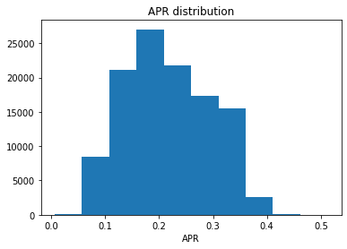

```python
hg(dfclean.BorrowerAPR,'APR','APR distribution')
```

> - We can see peak/mode for the Borrower's Annual Percentage Rate is arround 0.175%. The distribution is roughly unimodal and it shows there is less variance in the Borrower's APR. Most of the APR are between 0.05% - 0.4%.
> - Most of the loan were given for the APR between 0.15% - 0.2%.

### What is the distribution of the BorrowerRate

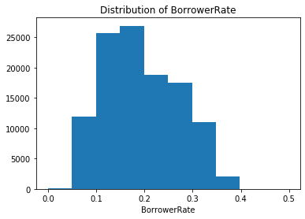

```python
hg(dfclean.BorrowerRate,'BorrowerRate','Distribution of BorrowerRate')
```

> - We can see the distribution is sligthly right skewed.
> - Interest rate are mostly between 0.1% - 0.3%.

### Which type Term i.e length of loan in months are given most ?

```python
dfclean.Term.value_counts()
```

```
36    87753
60    24545
12     1614
Name: Term, dtype: int64
```

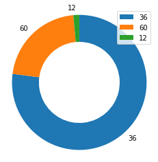

```python
sorted_counts = dfclean.Term.value_counts()
plt.pie(sorted_counts, labels = sorted_counts.index, startangle = 90,
        counterclock = False, wedgeprops = {'width' : 0.4});
plt.axis('square');
plt.legend();

#sns.countplot(dfclean.Term, order=[12,36,60], palette="Blues_r");
#plt.title("Count of Terms");
```

> - We can see most loan which are given are for 36 months.

### What are the status of loan in this dataset ?

```python
dfclean.LoanStatus.value_counts()
```

```
Current                   56576
Completed                 38049
Chargedoff                11992
Defaulted                  5018
Past Due (1-15 days)        806
Past Due (31-60 days)       363
Past Due (61-90 days)       313
Past Due (91-120 days)      304
Past Due (16-30 days)       265
FinalPaymentInProgress      205
Past Due (>120 days)         16
Cancelled                     5
Name: LoanStatus, dtype: int64
```

```python
#creating the list on index in decreasing order of Status
order_status = dfclean.LoanStatus.value_counts().index
```

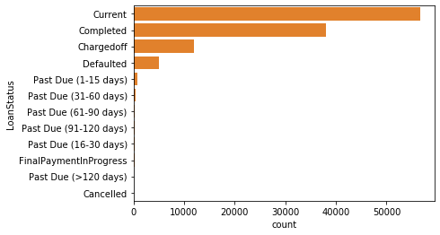

```python
sns.countplot(y = dfclean.LoanStatus, order=order_status,color=sns.color_palette()[1]);
```

> - Most loan status in this data set is Current which means most loan are in current term.
> - There are large number of records which also shows some Defaulters. However this graph does not show which type of loan or customer fall into which category. We will be exploring this in further analysis.

### What is distribution of LenderYeild ?

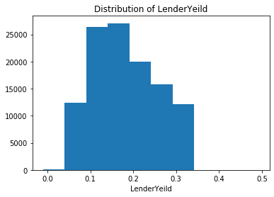

```python
hg(dfclean.LenderYield,'LenderYeild','Distribution of LenderYeild')
```

> Distribution looks roughly unimodal. Range is between 0.05% to 0.35%.

### What is Distribution of Loan Amount ?

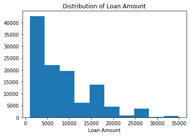

```python
hg(dfclean.LoanOriginalAmount,'Loan Amount','Distribution of Loan Amount')
```

> - We can see this is highly skewed towards right.
> - This means that most of the loan taken are of small amount between `$1000` to `$10000`.
> - We can explore more further to check for which loan amount there are most number of defaulters?

We can see there is small data for higher amount, we can apply transformation to loan amount data which can give better insights.

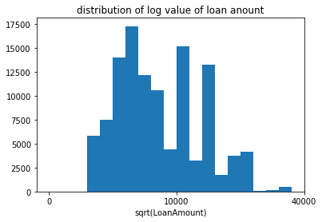

```python
def sqrt_trans(x, inverse = False):
    """ transformation helper function """
    if not inverse:
        return np.sqrt(x)
    else:
        return x ** 2

bin_edges = np.arange(0, sqrt_trans(dfclean.LoanOriginalAmount.max())+10, 10);
plt.hist(dfclean.LoanOriginalAmount.apply(sqrt_trans), bins = bin_edges);
tick_locs = np.arange(0, sqrt_trans(dfclean.LoanOriginalAmount.max())+100, 100);
plt.xticks(tick_locs, sqrt_trans(tick_locs, inverse = True).astype(int));
plt.title("distribution of log value of loan anount");
plt.xlabel("sqrt(LoanAmount)");
```

After transformation we can see the distribution more clearly with the higher amount loan also. Because minimum loan amount is 1000 , we can see there is no data in left most part of graph.

### In which Quarter most number of loans are given ?

```python
dfclean.LoanOriginationQuarter.nunique()
```

```
32
```

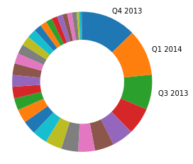

```python
name = [""] * len(dfclean.LoanOriginationQuarter.value_counts())
#name[:] = np.nan
c = dfclean.LoanOriginationQuarter.value_counts().index[0]
d = dfclean.LoanOriginationQuarter.value_counts().index[1]
e = dfclean.LoanOriginationQuarter.value_counts().index[2]
name[0:3] = c,d,e
sorted_counts = dfclean.LoanOriginationQuarter.value_counts()
plt.pie(sorted_counts, labels = name, startangle = 90,
        counterclock = False, wedgeprops = {'width' : 0.4});
plt.axis('square');
```

> - In Quarter 4 of 2013 , most number of loans are given followed by Q1 2014 and Q3 2013.

With this chart we get an idea for further exploration:

> - We can check why so many loans are given from July 2013 to March 2014. Was there any economic event going on?
> - We will explore if there any difference in Interest Rate or APR for the loan given during this time than normal time?
> - Maybe people took loans because interest rate was less? What loan amount are given during this time?

### Which Income Range of the persons are taking more loans?

```python
dfclean.IncomeRange.value_counts()
```

```
$25,000-49,999    32192
$50,000-74,999    31050
$100,000+         17337
$75,000-99,999    16916
Not displayed      7716
$1-24,999          7274
Not employed        806
$0                  621
Name: IncomeRange, dtype: int64
```

### Data Quality issue:

Not employed and 0 is a quality issue here. Data is not consistant. They both are same so this needs to be cleaned.

### Define

- Convert all the `Not employed` to `$0`

### Code

```python
dfclean.IncomeRange = dfclean.IncomeRange.str.replace('Not employed','$0')
```

### Test

```python
dfclean.IncomeRange.value_counts()
```

```
$25,000-49,999    32192
$50,000-74,999    31050
$100,000+         17337
$75,000-99,999    16916
Not displayed      7716
$1-24,999          7274
$0                 1427
Name: IncomeRange, dtype: int64
```

```python
# converting Income Range into ordered categorical types
ordinal_var_dict = {'IncomeRange': ['Not displayed','$0','$1-24,999','$25,000-49,999','$50,000-74,999','$75,000-99,999',
                                   '$100,000+']}


for var in ordinal_var_dict:
    pd_ver = pd.__version__.split(".")
    if (int(pd_ver[0]) > 0) or (int(pd_ver[1]) >= 21): # v0.21 or later
        ordered_var = pd.api.types.CategoricalDtype(ordered = True,
                                                    categories = ordinal_var_dict[var])
        dfclean[var] = dfclean[var].astype(ordered_var)
    else: # pre-v0.21
        dfclean[var] = dfclean[var].astype('category', ordered = True,
                                             categories = ordinal_var_dict[var])
```

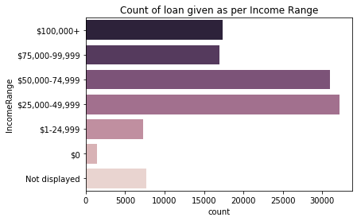

```python
#bar chart for Income range
base_color = sns.cubehelix_palette(dfclean.IncomeRange.nunique(),reverse=True) #(sns.cubehelix_palette(7))
sns.countplot(y = dfclean.IncomeRange,order=ordinal_var_dict['IncomeRange'][::-1],palette=base_color);
plt.title("Count of loan given as per Income Range");
```

> - We can observe that most people who are taking loans are in income range between `$25,000` to `$74,999`
> - Further we can see which type of loan these income range group are taking? What are the term & amount for the these loand?

### Discuss the distribution(s) of your variable(s) of interest. Were there any unusual points? Did you need to perform any transformations?

> Most of the distribution of features like BorrowerAPR, BorrowerRate, LenderYeild and LoanOriginalAmount are unimodal. Only LoanOriginalAmount has highly right skew distribution. Rest all features have less variation ans standard distribution.

### Of the features you investigated, were there any unusual distributions? Did you perform any operations on the data to tidy, adjust, or change the form of the data? If so, why did you do this?

> There is not much unsual distribution for most of the features. No feature shows outliers, only the LoanOriginalAmount has some data entry for higher loan amount, so I transformed it to square root transformation. This is to be done, if we are applying any linear model, or maybe we are predicting someting like defaulters or not, LoanOriginalAmount data will have higher impact than usual in predicting the result. Transformation will help us make our model and analysis bette.

## Bivariate Exploration

### Talk about some of the relationships you observed in this part of the investigation. How did the feature(s) of interest vary with other features in the dataset?

> In this section we will explore combinations like:
> - LoanStatus and LoanOriginalAmount
> - Avg BorrowerAPR from July 2013 to March 2014
> - Avg BorrowerAPR Trend per quarter
> - Avg BorrowerRate Trend per quarter
> - Avg LoanOriginalAmount in July 2013 to March 2014
> - Avg LoanAmount trend
> - IncomeRange and Loan Term
> - IncomeRange and Loan Amount

### What is the avg loan amount for different Loan Status? Specically avg loan amount for the defaulters?

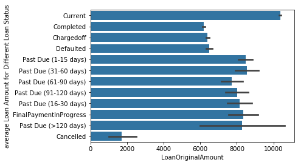

```python
order_status = dfclean.LoanStatus.value_counts().index
base_color = sns.color_palette()[0]
sns.barplot(data = dfclean, y = dfclean.LoanStatus, x = dfclean.LoanOriginalAmount, color=base_color, order=order_status); #to remove c.i line use errwidth = 0
#plt.xticks(rotation=90);
plt.ylabel("average Loan Amount for Different Loan Status")
```

#### This relation is very interesting. We can see many insights from this graph:

> - To answer the question, avg loan amount for the defaulters is around `$6500` with very less standard deviation.
> - Current loan amount is very high around 10000USD.
> - Cancelled loan are the loan which are of vert small amount.
> - Most of the loan which have passed due date are around 8000USD.
> - Standard deviation for the loan which are past due more than 120 days is highest.

#### Insights from this graph:

> - Small loans are tend to be cancelled most
> - Defaulters loan amount is not very less or not very high which makes it diffuct to predict if person will be a defaulter based on loan amount. We need to add different variable to predict such things.
> - Higher loan amount loan seems to have higher chances that customer will not pay before due date.

### What is relationship between BorroweAPR and Loan Amount ?

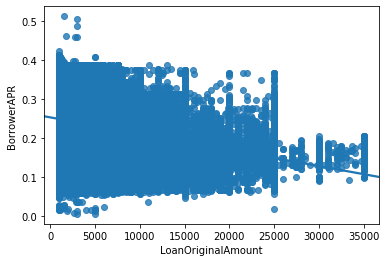

```python
sns.regplot(data = dfclean, y = dfclean.BorrowerAPR, x = dfclean.LoanOriginalAmount)
```

> This scatter plot is not clear because there are too many data points. We will make a heatmap for this.

> However, We can see regression line is showing negative relation, which means that as the loan amount increases, APR decreases.

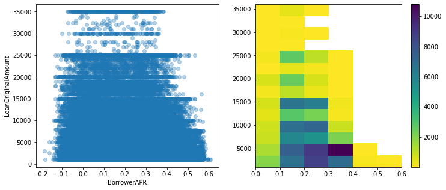

```python
#same plot with some difference
plt.figure(figsize = [12, 5])

# left plot: scatterplot of discrete data with jitter and transparency
plt.subplot(1, 2, 1)
sns.regplot(data = dfclean, x = dfclean.BorrowerAPR, y = dfclean.LoanOriginalAmount, fit_reg = False,
           x_jitter = 0.2, y_jitter = 0.2, scatter_kws = {'alpha' : 1/3})

# right plot: heat map with bin edges between values
plt.subplot(1, 2, 2)
bins_y = np.arange(1000, 35000+2500, 2500)
bins_x = np.arange(0, 0.6+0.1, 0.1)
plt.hist2d(data = dfclean, x = dfclean.BorrowerAPR, y = dfclean.LoanOriginalAmount, cmin = 0.1, #cmin removes if bin do not have min data in it
           bins = [bins_x, bins_y], cmap = 'viridis_r') #cmap for color
plt.colorbar();
```

> Scatter plot is not clear even after using jitter. This heat map shows most loans are small amount loan with avg APR around 0.3%.

### What is BorrowersAPR and BorrowerRate during from July 2013 to March 2014

```python
#filtering data for 'Q4 2013','Q1 2014','Q3 2013'
df1 = dfclean.query("LoanOriginationQuarter in ['Q4 2013','Q1 2014','Q3 2013']")
df1.head(2)
```

|  | ListingNumber | ListingCreationDate | Term | LoanStatus | BorrowerAPR | BorrowerRate | LenderYield | LoanNumber | LoanOriginalAmount | LoanOriginationDate | LoanOriginationQuarter | MemberKey | PercentFunded | Investors | IncomeRange |
| --- | --- | --- | --- | --- | --- | --- | --- | --- | --- | --- | --- | --- | --- | --- | --- |
| 1 | 1209647 | 2014-02-27 08:28:07.900 | 36 | Current | 0.12016 | 0.0920 | 0.0820 | 134815 | 10000 | 2014-03-03 | Q1 2014 | 1D13370546739025387B2F4 | 1.0 | 1 | $50,000-74,999 |
| 4 | 909464 | 2013-09-14 18:38:39.097 | 36 | Current | 0.24614 | 0.2085 | 0.1985 | 102670 | 15000 | 2013-09-20 | Q3 2013 | 36CE356043264555721F06C | 1.0 | 20 | $100,000+ |

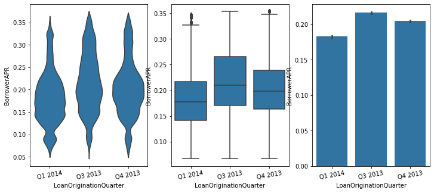

```python
plt.figure(figsize = [12, 5])
base_color = sns.color_palette()[0]

# left plot: violin plot
plt.subplot(1, 3, 1)
sns.violinplot(data = df1, x = df1.LoanOriginationQuarter, y = df1.BorrowerAPR, inner = None,
              color = base_color)
plt.xticks(rotation = 10); # include label rotation due to small subplot size

# center plot: box plot
plt.subplot(1, 3, 2)
sns.boxplot(data = df1, x = df1.LoanOriginationQuarter, y = df1.BorrowerAPR, color = base_color)
plt.xticks(rotation = 10);

# right plot: adapted bar chart
plt.subplot(1, 3, 3)
sns.barplot(data = df1, x = df1.LoanOriginationQuarter, y = df1.BorrowerAPR, color = base_color)
plt.xticks(rotation = 10);
```

### What is BorrowerAPR trend every quarter ?

```python
#creating a different column for quarter and year
dfclean['quarter'] = dfclean.LoanOriginationQuarter.apply(lambda x: x.split()[0])
dfclean['year'] = dfclean.LoanOriginationQuarter.apply(lambda x: x.split()[1])
```

```python
#Test to see if new columns are created
dfclean.head(2)
```

|  | ListingNumber | ListingCreationDate | Term | LoanStatus | BorrowerAPR | BorrowerRate | LenderYield | LoanNumber | LoanOriginalAmount | LoanOriginationDate | LoanOriginationQuarter | MemberKey | PercentFunded | Investors | IncomeRange | quarter | year |
| --- | --- | --- | --- | --- | --- | --- | --- | --- | --- | --- | --- | --- | --- | --- | --- | --- | --- |
| 0 | 193129 | 2007-08-26 19:09:29.263 | 36 | Completed | 0.16516 | 0.158 | 0.138 | 19141 | 9425 | 2007-09-12 | Q3 2007 | 1F3E3376408759268057EDA | 1.0 | 258 | $25,000-49,999 | Q3 | 2007 |
| 1 | 1209647 | 2014-02-27 08:28:07.900 | 36 | Current | 0.12016 | 0.092 | 0.082 | 134815 | 10000 | 2014-03-03 | Q1 2014 | 1D13370546739025387B2F4 | 1.0 | 1 | $50,000-74,999 | Q1 | 2014 |

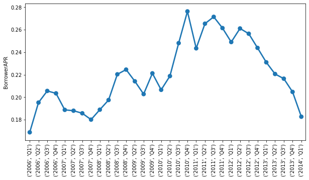

```python
#ploting a line graph.
plt.figure(figsize = [10, 5])

a = dfclean.groupby(['year','quarter']).BorrowerAPR.mean()
sns.pointplot(x=a.index,y=a);
plt.xticks(rotation=90);
```

> Clearly we can see there is a massive change in APR during 2013 and 2014. The APR kept falling during this time which might be the reason why so may people took loans.

### What is BorrowerRate trend every quarter ?

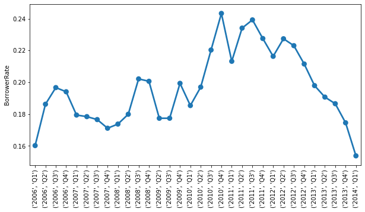

```python
#ploting a line graph.
plt.figure(figsize = [10, 5])

a = dfclean.groupby(['year','quarter']).BorrowerRate.mean()
sns.pointplot(x=a.index,y=a);
plt.xticks(rotation=90);
```

> As expected, Borrower interest Rate follows the same trend as BorrowerAPR.

### What is Average Loan Amount during July 2013 to March 2014?

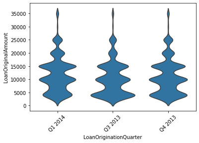

```python
base_color = sns.color_palette()[0]
sns.violinplot(data = df1, x = df1.LoanOriginationQuarter, y = df1.LoanOriginalAmount, color=base_color,inner = None) #remove inner for box pot inside
plt.xticks(rotation=45)
```

> There is not much difference in loan amount during this time. All type of loan are taken by the people. Small and Average amount of loans are more and few higher amount loans.

### What is Average Loan amount in the data set as per quarters?

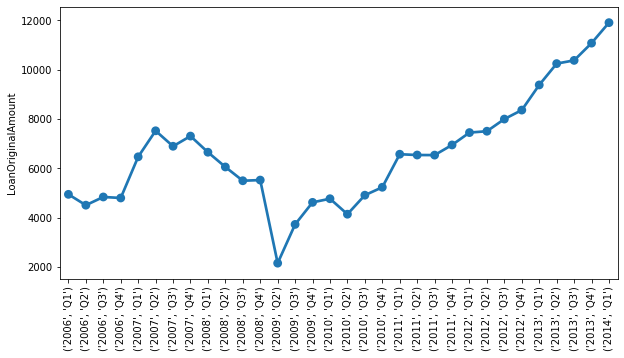

```python
#ploting a line graph.
plt.figure(figsize = [10, 5])

a = dfclean.groupby(['year','quarter']).LoanOriginalAmount.mean()
sns.pointplot(x=a.index,y=a);
plt.xticks(rotation=90);
```

> Trend shows an upward trend, this means more and more amount are taken as loans from past. This maybe because interest rate are going down, so people can take higher amount of loan with less risk.

### Which Income Range opt for which type of loan terms ?

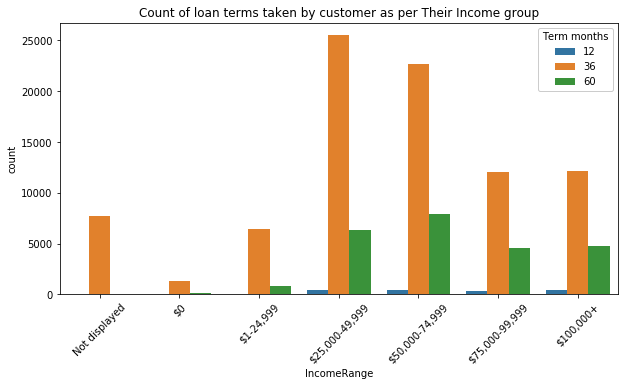

```python
plt.figure(figsize = [10, 5])
sns.countplot(data = dfclean,x=dfclean.IncomeRange, hue = dfclean.Term);
plt.xticks(rotation=45);
plt.legend(loc = 1, ncol = 1, framealpha = 1, title = 'Term months')
plt.title("Count of loan terms taken by customer as per Their Income group")
```

> All the income range groups are taking mid term i.e 36 months term loan maximum. There are other factors also affect this decision because longer term means more amount you will have to pay as interest. Similarly, lower term loans have high risk if you are unable to repay the loan amount. Further analysis is required for finding why most people opt for mid term loans.

### What is the Loan amount taken by different Income groups?

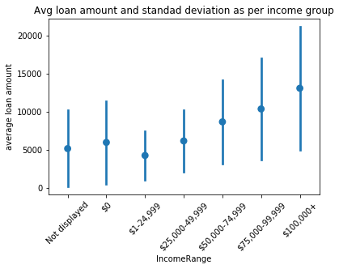

```python
sns.pointplot(data = dfclean, x = dfclean.IncomeRange, y = dfclean.LoanOriginalAmount , ci = 'sd',linestyles="");
plt.xticks(rotation=45);
plt.ylabel("average loan amount");
plt.title("Avg loan amount and standad deviation as per income group");
```

> We can observe a upward trend as we move up the order for income groups. Higher the imcome, higher is the avg loan amount. This maybe because higher income person can take more risk than lower income people. However standard deviation for highest income group is more which shows they also take small loans.

### Did you observe any interesting relationships between the other features (not the main feature(s) of interest)?

> During July 2013 to March 2014, number of loans is different for each quarter, however there is not much difference in amount of loan taken during this period despite the interest rate are going down.

> BorroweAPR, BorroweRate and LenderYield follows the same trend which shows there is not much variation in servicing fee.

## Multivariate Exploration

Now we will analyze these combinations:

### What is relation trend of APR and Loan amount over the years ?

```python
#ploting a line graph.
plt.figure(figsize = [10, 5])
b = dfclean.groupby(['year']).BorrowerAPR.mean()

a = dfclean.groupby(['year']).LoanOriginalAmount.mean()
a_log = np.log(a)
b_log = np.log10(b)
```

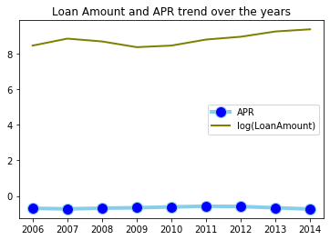

```python
# multiple line plot
plt.plot( a.index, b_log, marker='o', markerfacecolor='blue', markersize=12, color='skyblue', linewidth=4)
plt.plot( a.index, a_log, marker='', color='olive', linewidth=2)
plt.legend(["APR","log(LoanAmount)"]);
plt.title("Loan Amount and APR trend over the years")
```

### What is trend for BorrowerAPR per quarter from 2006 to 2014?

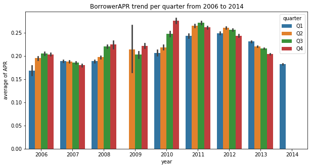

```python
plt.figure(figsize = [10, 5])

sns.barplot(data = dfclean, x = 'year', y = dfclean.BorrowerAPR ,hue = dfclean.quarter,hue_order=['Q1','Q2','Q3','Q4'],dodge=True);
plt.xticks();
plt.ylabel("average of APR",size= 10)
plt.title('BorrowerAPR trend per quarter from 2006 to 2014');
```

### What is trend for Loan Amount per quarter from 2006 to 2014?

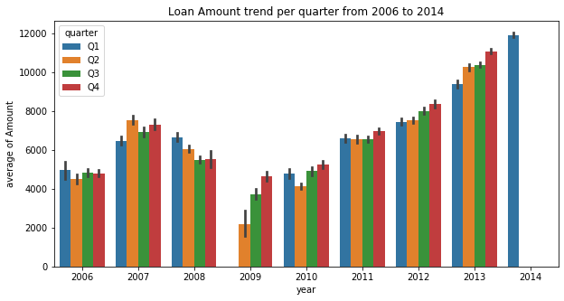

```python
plt.figure(figsize = [10, 5])

sns.barplot(data = dfclean, x = 'year', y = dfclean.LoanOriginalAmount ,hue = 'quarter',hue_order=['Q1','Q2','Q3','Q4'],dodge=True);
plt.xticks();
plt.ylabel("average of Amount",size= 10)
plt.title('Loan Amount trend per quarter from 2006 to 2014');
```

> Again the loan amount also shows unusual trend every quarter till 2009.Before year 2009, there was no usual trend from quarter to quarter.However, from 2009 the avg loan amount have shown an upward trend which means people are taking more money as loan over the years.

### what is relation between APR, loan amount during July 2013 to March 2014?

```python
#creating a different column for quarter and year
df1['quarter'] = df1.LoanOriginationQuarter.apply(lambda x: x.split()[0])
df1['year'] = df1.LoanOriginationQuarter.apply(lambda x: x.split()[1])
df1.year = pd.to_datetime(df1.year)
```

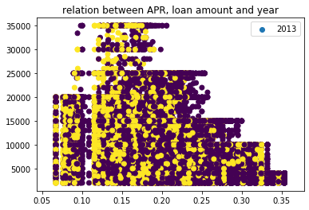

```python
# multivariate plot
#g = sns.FacetGrid(data = df1, hue = 'year', size = 5)
plt.scatter(df1.BorrowerAPR, df1.LoanOriginalAmount,c = df1.year)
plt.legend(['2013','2014']);
plt.title("relation between APR, loan amount and year");
```

> There are too many data points and there is no seperation between the years. It is difficult to find insight from this plot.

### Talk about some of the relationships you observed in this part of the investigation. Were there features that strengthened each other in terms of looking at your feature(s) of interest?

> This part shows the trend of BorrowerAPR and LoanOriginalAmount for every year, quarter to quarter. There is a a negative relationship between both the variable- APR and Loan Amount.